# The Local Linear Trend Model

The local linear trend model is obtained by adding a slope component $\nu_t$ to the local level model, as follows:

$$y_t = \mu_t + \epsilon_t, \qquad \epsilon_t \sim NID(0,{\sigma_\epsilon}^2)$$

$$\mu_{t+1} = \mu_t + \nu_t + \xi_t, \qquad \xi_t \sim NID(0,{\sigma_\xi}^2)$$
$$\nu_{t+1} = \nu_t + \zeta_t, \qquad \zeta_t \sim NID(0,{\sigma_\zeta}^2)$$

# Deterministic Level and Slope

Fixing all state disturbances $\xi_t$ and $\zeta_t$ in (3.1) on zero, it is easily verified that the linear trend model simplifies to:

$$y_t = \mu_1 + \nu_1 g_t + \epsilon_t, \qquad \epsilon_t \sim NID(0,{\sigma_\epsilon}^2)$$
for $t = 1,...,n$, where the predictor variable $g_t = t − 1$ for $t = 1,...,n$ is effectively time, and $\mu_1$ and $\nu_1$ are the initial values of the level and the slope. The latter equation can also be written as

$$y_t = (\mu_1 - \nu_1) + \nu_1(g_t +1) + \epsilon_t \\
\quad = (\mu_1 - \nu_1) + \nu_1 x_t + \epsilon_t$$

with $x_t = g_t + 1 = t = 1,2,...,n$.

## Using Ordinary Least Squares

$$y_t = (\mu_1 - \nu_1) + \nu_1(g_t +1) + \epsilon_t \\
\quad = (\mu_1 - \nu_1) + \nu_1 x_t + \epsilon_t \\
\quad = \alpha + \beta x_t + \epsilon_t$$

with $\alpha = (\mu_1 - \nu_1)$ and $\beta = \nu_1$

The analysis of the log of the number of UK drivers KSI series using a simple linear regression yields the following results:

```r
# Pacotes
require("xts")
```

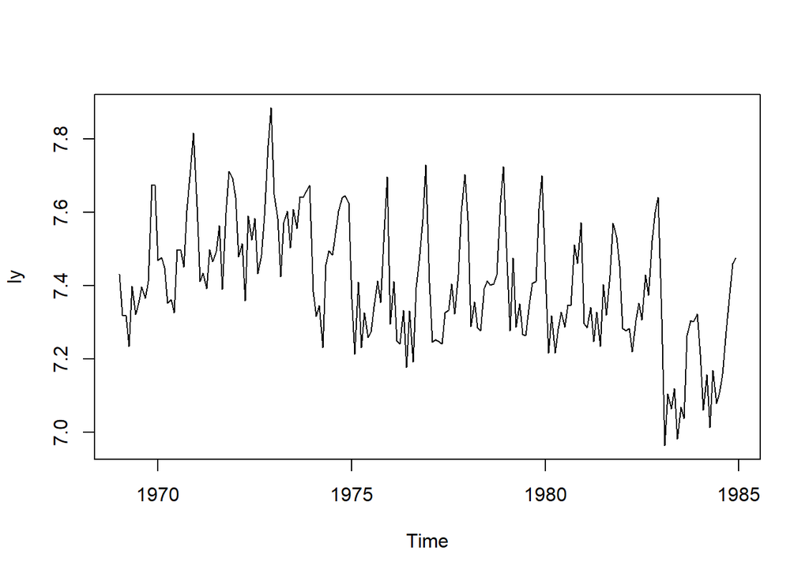

```r
# Declara o conjunto de dados
y = datasets::UKDriverDeaths
ly = log(y)

# Plot da serie
ts.plot(ly)
```

```r
# OLS
t = index(index(ly))
OLS = lm(ly~t)

# Resultados
summary(OLS)
```

```
##
## Call:
## lm(formula = ly ~ t)
##
## Residuals:
##      Min       1Q   Median       3Q      Max
## -0.33649 -0.10850 -0.01256  0.10368  0.40749
##
## Coefficients:
##               Estimate Std. Error t value Pr(>|t|)
## (Intercept)  7.5458427  0.0219747 343.387  < 2e-16 ***
## t           -0.0014480  0.0001975  -7.333 6.31e-12 ***
## ---
## Signif. codes:  0 '***' 0.001 '**' 0.01 '*' 0.05 '.' 0.1 ' ' 1
##
## Residual standard error: 0.1517 on 190 degrees of freedom
## Multiple R-squared:  0.2206, Adjusted R-squared:  0.2165
## F-statistic: 53.77 on 1 and 190 DF,  p-value: 6.313e-12
```

The resulting model is:

$$\hat{y_t} = 7.5458 - 0.00145 x_t$$

## Using Proposed Algorithm

The analysis of the log of the number of UK drivers KSI series using R implementation of the proposed algorithm, with package “dlm” yields the following results:

```r
# Pacote
require("dlm")
# Modelo - Variancias das equacoes de estado fixas em 0
fn <- function(params){
        dlmModPoly(order = 2, dV = exp(params[1]), dW = c(0,0))
}

# MLE
fit = dlmMLE(ly, rep(0,1), fn)

# Aplicando os parametros MLE no modelo
mod = fn(fit$par)

# Parametros - Variancias - Observacao (Componente Irregular) e Estado
obs.err = V(mod)
sta.err = W(mod)

print(obs.err[1,1])
```

```
## [1] 0.02299806
```

```r
print(sta.err[1,1])
```

```
## [1] 0
```

```r
print(sta.err[2,2])
```

```
## [1] 0
```

```r
# Aplica o filtro de Kalman
km = dlmFilter(ly,mod)

# Suavizacao
kms = dlmSmooth(km)
sm = dropFirst(kms$s)

# Parametros - Valores iniciais
val0 = sm[1,]

print(val0)
```

```
##     Series 1     Series 2
##  7.544394699 -0.001447801
```

As expected, the result is the same:

$$\hat{y_t} = (7.5444 - (-0.00145)) - 0.00145 x_t \\
\quad = 7.5458 - 0.00145 x_t$$

# Stochastic Level and Slope

Allowing both the level and the slope to vary over time in model, the following results are obtained:

```r
# Modelo
level0 = ly[1]
slope0 = mean(diff(ly))

fn <- function(params){
    dlmModPoly(dV = exp(params[1]), dW = exp(params[2:3]),
               m0 = c(level0, slope0), C0 = 2*diag(2))
  }

# MLE
fit = dlmMLE(ly, rep(0,3), fn)

# Aplicando os parametros MLE no modelo
mod = fn(fit$par)

# Parametros - Variancias - Observacao (Componente Irregular) e Estado
obs.err = V(mod)
sta.err = W(mod)

print(obs.err[1,1])
```

```
## [1] 0.002118253
```

```r
print(sta.err[1,1])
```

```
## [1] 0.01212771
```

```r
print(sta.err[2,2])
```

```
## [1] 1.518294e-11
```

```r
# Aplica o filtro de Kalman
km = dlmFilter(ly,mod)

# Suavizacao
kms = dlmSmooth(km)
sm = dropFirst(kms$s)

# Parametros - Valores iniciais
val0 = sm[1,]

print(val0)
```

```
##    Series 1    Series 2
## 7.415748246 0.000288407
```

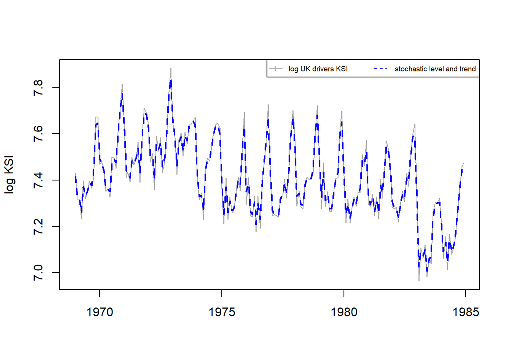

```r
# Plot da serie original
plot.ts(ly, col = "darkgrey", xlab="",ylab = "log KSI",pch=3,cex=0.5,
            cex.lab=0.8,cex.axis=0.7)

# Adiciona o modelo estimado
lines(dropFirst(kms$s[,1]) , col = "blue", lwd = 2, lty=2)

# Legenda
legend("topright",leg = c("log UK drivers KSI"," stochastic level and trend"),
      cex = 0.6,lty = c(1, 2), col = c("darkgrey","blue"), pch=c(3,NA), bty = "y", horiz = T)
```

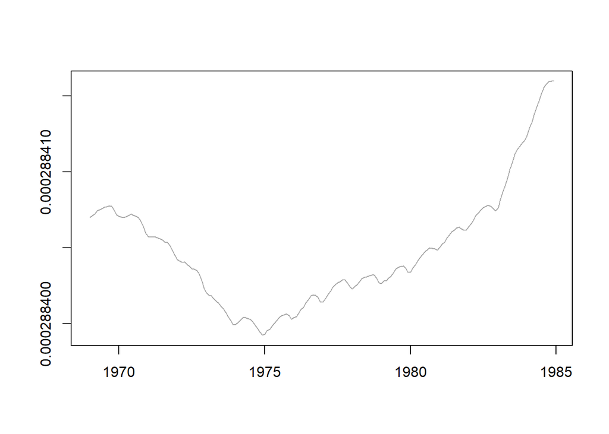

```r
# Plot do componente de tendencia (slope)
plot.ts(dropFirst(kms$s[,2]), col = "darkgrey", xlab="",ylab = "")
```

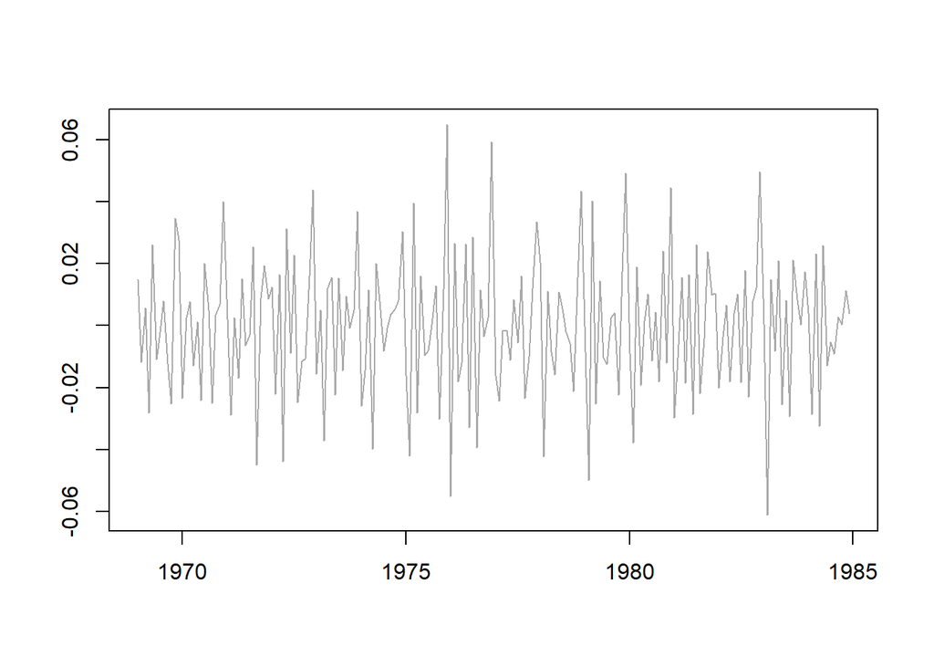

```r
# Plot do componente irregular (epsilon)
plot.ts((ly-dropFirst(kms$s[,1])), col = "darkgrey", xlab="",ylab = "")
```

# Stochastic Level and Deterministic Slope

Another possibility is to consider a model where only the level is allowed to vary over time whereas the slope is treated deterministically. In this case it is not very difficult to verify that model can be written as

$$y_t = \mu_t + \epsilon_t, \qquad \epsilon_t \sim NID(0,{\sigma_\epsilon}^2)$$

$$\mu_{t+1} = \mu_t + \nu_1 + \xi_t, \qquad \xi_t \sim NID(0,{\sigma_\xi}^2)$$
The analysis of the log of the UK drivers KSI with this model yields the following results:

```r
# Modelo
fn <- function(params){
    dlmModPoly(dV = exp(params[1]), dW = c(exp(params[2]),0))
  }

# MLE
fit = dlmMLE(ly, rep(0,2), fn)

# Aplicando os parametros MLE no modelo
mod = fn(fit$par)

# Parametros - Variancias - Observacao (Componente Irregular) e Estado
obs.err = V(mod)
sta.err = W(mod)

print(obs.err[1,1])
```

```
## [1] 0.002118081
```

```r
print(sta.err[1,1])
```

```
## [1] 0.01212834
```

```r
print(sta.err[2,2])
```

```
## [1] 0
```

```r
# Aplica o filtro de Kalman
km = dlmFilter(ly,mod)

# Suavizacao
kms = dlmSmooth(km)
sm = dropFirst(kms$s)

# Parametros - Valores iniciais
print(sm[1,1])
```

```
## Series 1
## 7.415736
```

```r
print(sm[2,2])
```

```
##     Series 2
## 0.0002889568
```

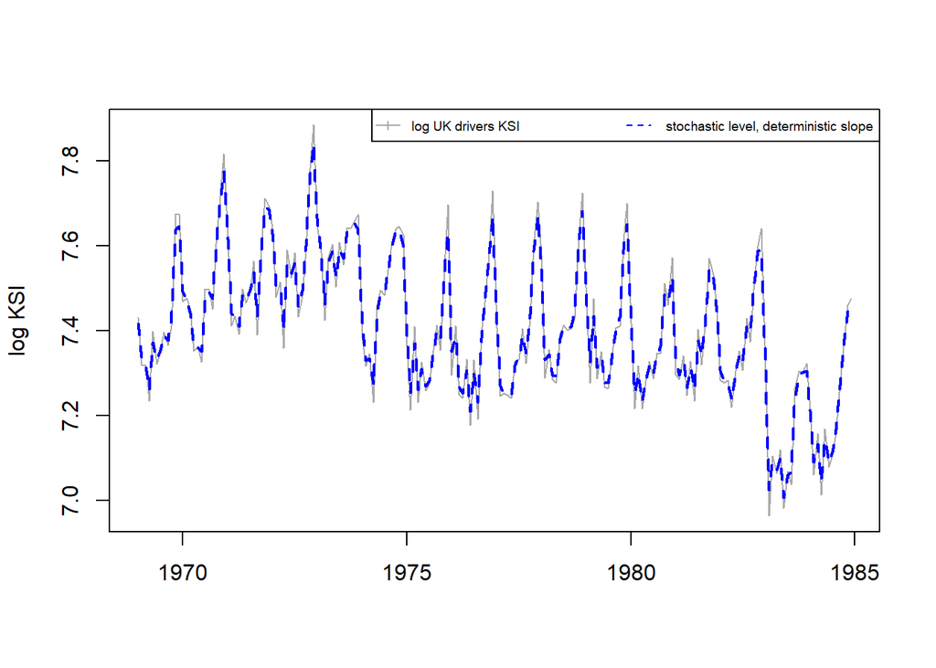

```r
# Plot da serie original
plot.ts(ly, col = "darkgrey", xlab="",ylab = "log KSI",pch=3,cex=0.5,
            cex.lab=0.8,cex.axis=0.7)

# Adiciona o modelo estimado
lines(dropFirst(kms$s[,1]) , col = "blue", lwd = 2, lty=2)

# Legenda
legend("topright",leg = c("log UK drivers KSI"," stochastic level, deterministic slope"),
      cex = 0.6,lty = c(1, 2), col = c("darkgrey","blue"), pch=c(3,NA), bty = "y", horiz = T)
```

The state space models discussed in the present book are regression models in which the parameters (intercept and regression coefficient(s)) are allowed to vary over time. State space models are therefore also sometimes referred to as *dynamic linear models*.